# CEU-Intermediate Quantitative Social Research-Assignment 1

Luka Zeravica

10/26/2020

CEU-Intermediate Quantitative Social Research-Assignment 1

##1.1

```r
setwd ("C:/Users/lukaz/Documents/R programming/Exercise 1")
gay <- read.csv("gay.csv")
ccap2012 <- read.csv("ccap2012.csv")
gayreshaped <- read.csv("gayreshaped.csv")
summary(gay)
```

```
##      study        treatment              wave            ssm
##  Min.   :1.000   Length:69592       Min.   :1.000   Min.   :1.000
##  1st Qu.:1.000   Class :character   1st Qu.:2.000   1st Qu.:1.000
##  Median :1.000   Mode  :character   Median :4.000   Median :3.000
##  Mean   :1.149                      Mean   :3.753   Mean   :3.107
##  3rd Qu.:1.000                      3rd Qu.:5.000   3rd Qu.:5.000
##  Max.   :2.000                      Max.   :7.000   Max.   :5.000
```

```r
summary(gayreshaped)
```

```
##      study        treatment             therm1           therm2
##  Min.   :1.000   Length:11948       Min.   :  0.00   Min.   :  0.00
##  1st Qu.:1.000   Class :character   1st Qu.: 48.00   1st Qu.: 45.00
##  Median :1.000   Mode  :character   Median : 52.00   Median : 55.00
##  Mean   :1.204                      Mean   : 58.43   Mean   : 58.68
##  3rd Qu.:1.000                      3rd Qu.: 84.00   3rd Qu.: 84.00
##  Max.   :2.000                      Max.   :100.00   Max.   :100.00
##                                                      NA's   :1351
##      therm3           therm4
##  Min.   :  0.00   Min.   :  0.00
##  1st Qu.: 44.00   1st Qu.: 44.00
##  Median : 57.00   Median : 58.00
##  Mean   : 59.72   Mean   : 59.76
##  3rd Qu.: 85.00   3rd Qu.: 85.00
##  Max.   :100.00   Max.   :100.00
##  NA's   :9835     NA's   :9777
```

```r
summary(ccap2012)
```

```
##        X             caseid          gaytherm
##  Min.   :    1   Min.   :   1.0   Min.   :  0.00
##  1st Qu.:11000   1st Qu.: 251.0   1st Qu.: 45.00
##  Median :22000   Median : 501.0   Median : 54.00
##  Mean   :22000   Mean   : 500.5   Mean   : 58.71
##  3rd Qu.:32999   3rd Qu.: 751.0   3rd Qu.: 85.00
##  Max.   :43998   Max.   :1001.0   Max.   :100.00
##                                   NA's   :3097
```

```r
gay$treatment= as.factor(gay$treatment)
gayreshaped$treatment= as.factor(gayreshaped$treatment)
class(gayreshaped$treatment)
```

```
## [1] "factor"
```

##1.2

```r
prop.table(table(gay$ssm))
```

```
##
##         1         2         3         4         5
## 0.2724882 0.1386079 0.1129728 0.1615559 0.3143752
```

```r
prop.table(table(gay$treatment))
```

```
##
##                                     No Contact
##                                     0.54223187
##              Recycling Script by Gay Canvasser
##                                     0.09360271
##         Recycling Script by Straight Canvasser
##                                     0.09302793
##      Same-Sex Marriage Script by Gay Canvasser
##                                     0.17892861
## Same-Sex Marriage Script by Straight Canvasser
##                                     0.09220887
```

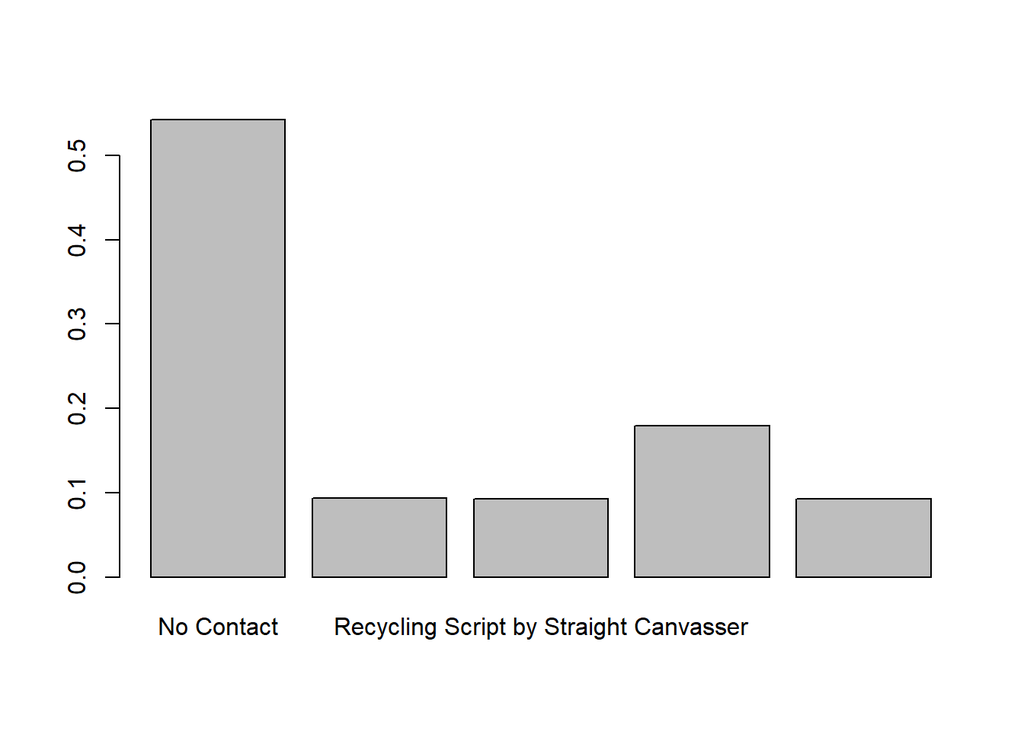

```r
treatment <- prop.table(table(gay$treatment))
ssm <- prop.table(table(gay$ssm))
barplot(treatment)
```

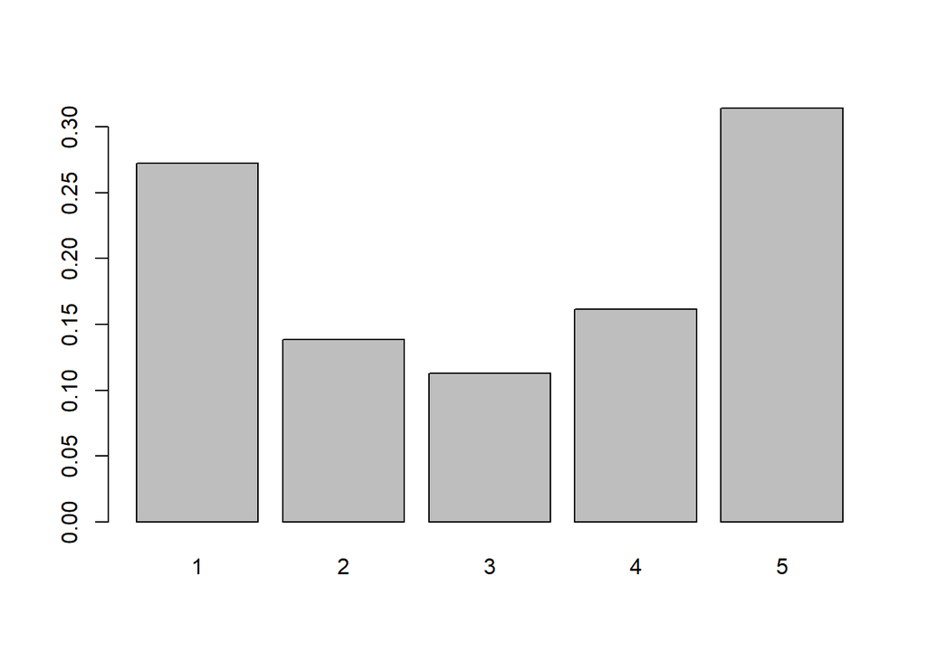

```r
barplot(ssm)
```

##1.3

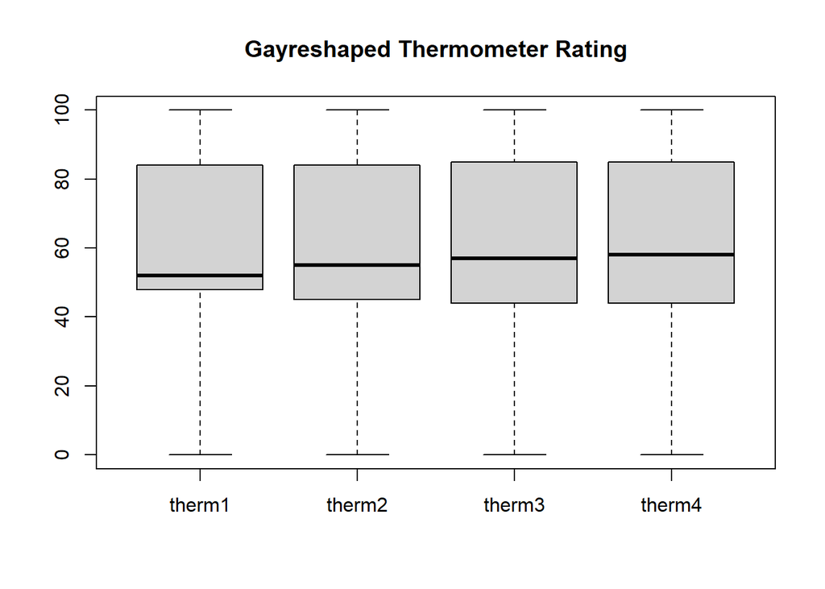

```r
boxplot(gayreshaped$therm1, gayreshaped$therm2, gayreshaped$therm3, gayreshaped$therm4, main= "Gayreshaped Thermometer Rating", names =c("therm1", "therm2", "therm3", "therm4"))
```

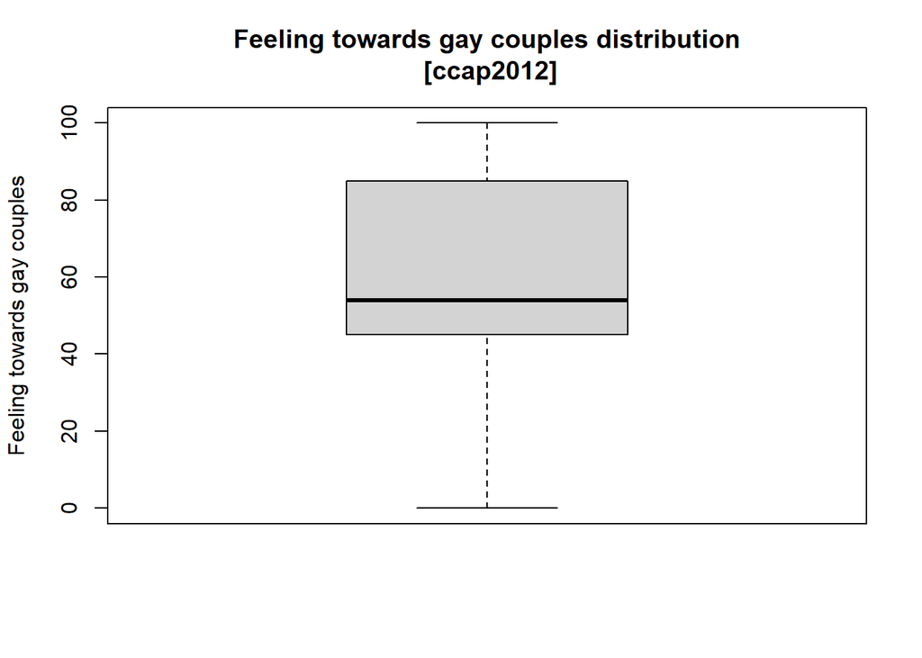

```r
main="Thermometer Rating"
boxplot(ccap2012$gaytherm, main="Feeling towards gay couples distribution\n [ccap2012]",ylab= "Feeling towards gay couples")
```

The boxplots show four therms that have range. Every median is located between 50 and 60 values. The range of outliers starts from near 0 and ends near 100. The range of median is pretty close (between 50 and 60 value). Median values are similar in all therms, except for little variation in therm 1.

##1.4

```r
gay$ssm <- as.numeric(gay$ssm)
nocontact.wl.sl <- subset(gay, subset = (treatment=="No Contact") & (study==1) & (wave==1))
gay3.w1.s1<-subset(gay,subset = (treatment=="Same-Sex Marriage Script by Gay Canvasser")& (study==1)& (wave==1))
straight.w1.s1<-subset(gay, subset = (treatment=="Same-Sex Marriage Script by Straight Canvasser")& (study==1)&(wave==1))
mean(nocontact.wl.sl$ssm,rm.na=T)
```

```
## [1] 3.042764
```

```r
mean(gay3.w1.s1$ssm, rm.na=T)
```

```
## [1] 3.025195
```

The average treatment effects of gay and straight canvassers on support for same-sex marriage have a similar percentage of means result. Therefore, randomization was done properly.

##1.5

```r
nocontact.w2.sl <- subset(gay, subset = (treatment=="No Contact") & (study==1) & (wave==2))
gay3.w2.s1<-subset(gay,subset = (treatment=="Same-Sex Marriage Script by Gay Canvasser")& (study==1)& (wave==2))
straight.w2.s1<-subset(gay, subset = (treatment=="Same-Sex Marriage Script by Straight Canvasser")& (study==1)&(wave==2))
mean(nocontact.w2.sl$ssm,rm.na=T)
```

```
## [1] 3.039615
```

```r
mean(gay3.w2.s1$ssm, rm.na=T)
```

```
## [1] 3.139489
```

```r
mean(straight.w2.s1$ssm,rm.na=T)
```

```
## [1] 3.161863
```

```r
mean(gay3.w2.s1$ssm, rm.na=T)-mean(nocontact.w2.sl$ssm,rm.na=T)
```

```
## [1] 0.09987463
```

```r
mean(straight.w2.s1$ssm,rm.na=T)-mean(nocontact.w2.sl$ssm,rm.na=T)
```

```
## [1] 0.122248
```

##1.6

```r
recycling.straight.w2.s1<-subset(gay,subset = (treatment=="Recycling Script by Straight Canvasser" & (study==1) & (wave==2)))
recycling.gay.w2.s1<-subset(gay,subset = (treatment=="Recycling Script by Gay Canvasser" & (study==1) & (wave==2)))
mean(gay3.w2.s1$ssm)-mean(recycling.gay.w2.s1$ssm)
```

```
## [1] 0.03204239
```

```r
mean(straight.w2.s1$ssm)-mean(recycling.straight.w2.s1$ssm)
```

```
## [1] 0.1575845
```

The recycling script is a counterfactual. Also, there is a greater difference in the difference of means between recycling script by straight canvasser and same-sex marriage script by straight.

##1.7

```r
gay.s1.t1_t4 <- gay[gay$study == "1" & gay$treatment != "Recycling Script by Gay Canvasser",]
gay.s1.t1_t4 <- gay.s1.t1_t4[gay.s1.t1_t4$treatment != "Recycling Script by Straight Canvasser",]
a = tapply(gay.s1.t1_t4$ssm, list(gay.s1.t1_t4$treatment, gay.s1.t1_t4$wave), mean)
a
```

```
##                                                       1        2        3
## No Contact                                     3.042764 3.039615 3.046273
## Recycling Script by Gay Canvasser                    NA       NA       NA
## Recycling Script by Straight Canvasser               NA       NA       NA
## Same-Sex Marriage Script by Gay Canvasser      3.025195 3.139489 3.127639
## Same-Sex Marriage Script by Straight Canvasser 3.099710 3.161863 3.106681
##                                                       4        5        6
## No Contact                                     3.035946 3.174272 3.091973
## Recycling Script by Gay Canvasser                    NA       NA       NA
## Recycling Script by Straight Canvasser               NA       NA       NA
## Same-Sex Marriage Script by Gay Canvasser      3.128571 3.322167 3.178408
## Same-Sex Marriage Script by Straight Canvasser 3.123142 3.272827 3.155488
##                                                       7
## No Contact                                     3.313747
## Recycling Script by Gay Canvasser                    NA
## Recycling Script by Straight Canvasser               NA
## Same-Sex Marriage Script by Gay Canvasser      3.373116
## Same-Sex Marriage Script by Straight Canvasser 3.271210
```

```r
(a[4,2:7]-a[4,1:6])-(a[1,2:7]-a[1,1:6])
```

```
##           2           3           4           5           6           7
##  0.11744357 -0.01850851  0.01125964  0.05526967 -0.06145995 -0.02706713
```

```r
(a[5,2:7]-a[5,1:6])-(a[1,2:7]-a[1,1:6])
```

```
##           2           3           4           5           6           7
##  0.06530280 -0.06183996  0.02678858  0.01135864 -0.03503999 -0.10605245
```

Here is used the method of difference-in-difference. Based on calculus, we can see that difference in some waves has a negative value, but others have a positive value. If there is a negative value, then treatment has no effect. If it is positive, the treatment has an effect. Since the time interval between wave 6 and wave 7 amounts to one year, it can be inferred that after a longer time period, the effect of gay and straight canvassing treatment does not have an effect.

##1.8

```r
gay$ssm<-as.numeric(gay$ssm)
nocontact.s2.w1<-subset(gay,subset = (treatment=="No Contact")&(study==2)&(wave==1))
gay3.s2wave1<-subset(gay,subset = (treatment=="Same-Sex Marriage Script by Gay Canvasser")&(study==2)&(wave==1))
mean(nocontact.s2.w1$ssm)
```

```
## [1] 2.970075
```

```r
mean(gay3.s2wave1$ssm)
```

```
## [1] 2.971729
```

In the second study, the mean for no contact and the same-sex marriage script by a gay canvasser resulted around 2.97. A similar mean is expected, which means that the randomization of both groups was appropriately done. It seems like both groups have the same characteristics.

##1.9

```r
nocontact.w2.s2 <- subset(gay, subset = (treatment=="No Contact") & (study==2) & (wave==2))

gay3.w2.s2 <- subset(gay, subset = (treatment=="Same-Sex Marriage Script by Gay Canvasser") & (study==2) & (wave==2))

mean(gay3.w2.s1$ssm) - mean(nocontact.w2.sl$ssm)
```

```
## [1] 0.09987463
```

```r
mean(gay3.w2.s2$ssm) - mean(nocontact.w2.s2$ssm)
```

```
## [1] 0.1238937
```

In study 2, the treatment effect of gay canvassing amounts to 12.38% compared to no contact. In study 1, the treatment effect of gay canvassing amounts to 9.98%. The results are consistent between studies even though the treatment effect is greater in study 2, but there is a similar increase in treatment effect in study 1.

##1.10

```r
nocontact.s2 <- subset(gay, subset = (treatment=="No Contact") & (study==2))

gay3.s2 <- subset(gay, subset = (treatment=="Same-Sex Marriage Script by Gay Canvasser") & (study==2))

tapply(gay3.s2$ssm, gay3.s2$wave, mean) - tapply(nocontact.s2$ssm, nocontact.s2$wave, mean)
```

```
##           1           2           3           4           7
## 0.001653782 0.123893673 0.150420627 0.125173822 0.307062649
```

There are average or mean differences between same-sex marriage gay canvasser treatments in study 2, which occur in different waves. For instance, the difference between second, third, and fourth-wave mean is minuscule, but between first and seventh and others, there is a significant difference. It should be noted that the time interval between the first and fourth mean was two months. Waves 4 and 7 were conducted within a time interval of one year. Likewise, there is a positive difference between all waves except between weave 3 and 4 (where the difference was negative). This indicates that changes were not coherent enough.

##1.11

```r
gayreshapedsubset1 <- gayreshaped$therm1[gayreshaped$treatment == "No Contact" & gayreshaped$study==1]

gayreshapedsubset2 <- gayreshaped$therm2[gayreshaped$treatment == "No Contact" & gayreshaped$study == 1]

cor(gayreshapedsubset1, gayreshapedsubset2, use = "complete.obs")
```

```
## [1] 0.9975817
```

The correlation between respondents’ feeling thermometer ratings in waves 1 and 2 for the control group in study 1 amounts to 99%. This is an unusually unlikely high percentage of correlation.

##1.12

```r
nocontact.s2.gayreshaped <- subset(gayreshaped, subset =(study == 2) & (treatment == "No Contact"))

cor(nocontact.s2.gayreshaped[,3:6], use = "pairwise.complete.obs")
```

```
##           therm1    therm2    therm3    therm4
## therm1 1.0000000 0.9734449 0.9594085 0.9709017
## therm2 0.9734449 1.0000000 0.9308287 0.9436621
## therm3 0.9594085 0.9308287 1.0000000 0.9343249
## therm4 0.9709017 0.9436621 0.9343249 1.0000000
```

Between four waves, the correlation varies from 93% to 97%. This percentage of the results are starting to cast doubt about the research itself.

##1.13

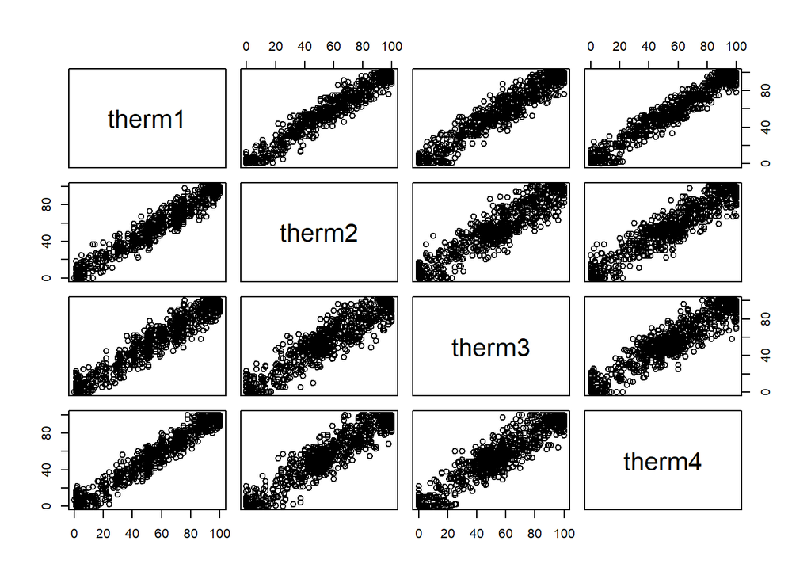

```r
plot(nocontact.s2.gayreshaped[,3:6])
```

The scatterplots confirm previous assumptions. It shows that the correlation is suspiciously high. This means that the respondents gave the same answers after a more extended period of time. It looks like the research is rigged.